# Task 20

Hayden Armour

11/15/2022

Recreating Case 8

```r
library(knitr)
library(tidyverse)
```

```r
library(downloader)
library(corrplot)
library(stringi)
library(lubridate)
library(riem)
library(gifski)
library(gganimate)
```

```r
tempsales <- tempfile()

download("https://github.com/WJC-Data-Science/DTS350/raw/master/sales.csv", tempsales, mode = "wb")

sales <- read_csv(tempsales)
head(sales)
```

```
## # A tibble: 6 × 4
##   Name       Type           Time                Amount
##   <chr>      <chr>          <dttm>               <dbl>
## 1 Tacontento Food(prepared) 2016-05-16 19:01:00    3
## 2 Tacontento Food(prepared) 2016-05-16 19:01:00    1.5
## 3 Tacontento Food(prepared) 2016-05-16 19:04:00    3
## 4 Tacontento Food(prepared) 2016-05-16 19:04:00    3
## 5 Tacontento Food(prepared) 2016-05-16 19:04:00    1.5
## 6 Tacontento Food(prepared) 2016-05-16 19:04:00    1
```

The data are for businesses in the mountain time zone. Make sure you read in times correctly.

```r
salestz <- with_tz(sales, tzone = "US/Mountain")

head(salestz)
```

```
## # A tibble: 6 × 4
##   Name       Type           Time                Amount
##   <chr>      <chr>          <dttm>               <dbl>
## 1 Tacontento Food(prepared) 2016-05-16 13:01:00    3
## 2 Tacontento Food(prepared) 2016-05-16 13:01:00    1.5
## 3 Tacontento Food(prepared) 2016-05-16 13:04:00    3
## 4 Tacontento Food(prepared) 2016-05-16 13:04:00    3
## 5 Tacontento Food(prepared) 2016-05-16 13:04:00    1.5
## 6 Tacontento Food(prepared) 2016-05-16 13:04:00    1
```

```r
tail(salestz)
```

```
## # A tibble: 6 × 4
##   Name    Type               Time                Amount
##   <chr>   <chr>              <dttm>               <dbl>
## 1 Frozone Food(pre-packaged) 2016-07-09 17:58:00   5
## 2 Frozone Food(pre-packaged) 2016-07-09 18:33:00   5
## 3 Frozone Food(pre-packaged) 2016-07-09 18:37:00   5
## 4 Frozone Food(pre-packaged) 2016-07-09 18:47:00   5
## 5 Missing Missing            2016-06-17 15:12:00 150
## 6 Missing Missing            2016-04-20 13:01:00  -3.07
```

This is point of sale (pos) data, so you will need to use library(lubridate) to create the correct time aggregations.

```r
timedata <- salestz %>%
  mutate(hourofday = hour(Time)) %>%
  mutate(dayofweek = wday(Time, label = TRUE, abbr = FALSE)) %>%
  mutate(weekofyear = week(Time)) %>%
  mutate(monthofyear = month(Time))

tail(timedata)
```

```
## # A tibble: 6 × 8
##   Name    Type        Time                Amount houro…¹ dayof…² weeko…³ month…⁴
##   <chr>   <chr>       <dttm>               <dbl>   <int> <ord>     <dbl>   <dbl>
## 1 Frozone Food(pre-p… 2016-07-09 17:58:00   5         17 Saturd…      28       7
## 2 Frozone Food(pre-p… 2016-07-09 18:33:00   5         18 Saturd…      28       7
## 3 Frozone Food(pre-p… 2016-07-09 18:37:00   5         18 Saturd…      28       7
## 4 Frozone Food(pre-p… 2016-07-09 18:47:00   5         18 Saturd…      28       7
## 5 Missing Missing     2016-06-17 15:12:00 150         15 Friday       25       6
## 6 Missing Missing     2016-04-20 13:01:00  -3.07      13 Wednes…      16       4
## # … with abbreviated variable names ¹hourofday, ²dayofweek, ³weekofyear,
## #   ⁴monthofyear
```

Help your boss understand which business is the best investment through visualizations.

Provide an understanding and recommendation for hours of operation.

```r
hourofoperation <- timedata %>%
  group_by(Name, hourofday) %>%
  select(Name, Amount, hourofday)

head(hourofoperation)
```

```
## # A tibble: 6 × 3
## # Groups:   Name, hourofday [1]
##   Name       Amount hourofday
##   <chr>       <dbl>     <int>
## 1 Tacontento    3          13
## 2 Tacontento    1.5        13
## 3 Tacontento    3          13
## 4 Tacontento    3          13
## 5 Tacontento    1.5        13
## 6 Tacontento    1          13
```

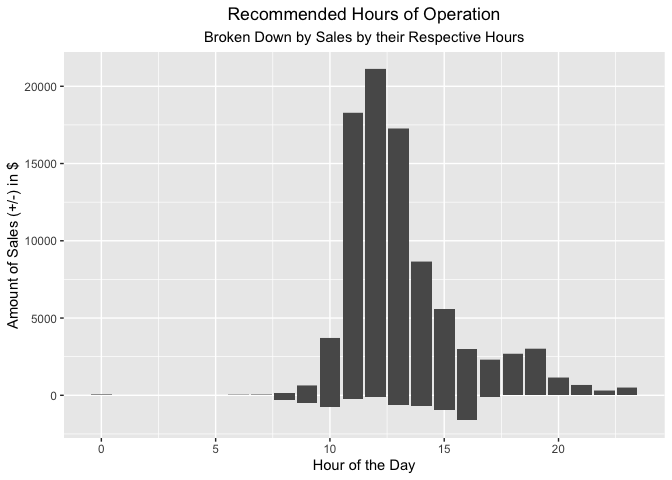

```r
ggplot(data = hourofoperation, mapping = aes(x = hourofday, y = Amount)) +
  geom_col() +
  labs(title = "Recommended Hours of Operation", subtitle = "Broken Down by Sales by their Respective Hours", x = "Hour of the Day", y = "Amount of Sales (+/-) in $") +
  theme(plot.title = element_text(hjust = .5)) +
  theme(plot.subtitle = element_text(hjust = .5))
```

We can see here, that the optimal hours of operation would be from 9am-8pm. There are some hour-intervals included that go below the x-axis, but it is negated by the height on the y. They ultimately make money, but incur some sort of costs along the way.

Customer traffic is greatest between the hours of 11am and 2pm. It is virtually none between the hours of 12am and 7 am, and sees more traffic between 8am and 11pm.

```r
ex <- hourofoperation %>% filter(Name != "Missing")
tail(ex)
```

```
## # A tibble: 6 × 3
## # Groups:   Name, hourofday [3]
##   Name    Amount hourofday
##   <chr>    <dbl>     <int>
## 1 Frozone      3        16
## 2 Frozone      5        17
## 3 Frozone      5        17
## 4 Frozone      5        18
## 5 Frozone      5        18
## 6 Frozone      5        18
```

Animated Graph

[output not shown]

[figure not shown]

```r
preplot <- ggplot(data = ex, mapping = aes(x = hourofday, y = Amount, color = Name)) +
  geom_line() +
  facet_wrap(~Name) +
  labs(title = "Recomended Hours of Operation", subtitle = "Broken Down by Sales by their Respective Hours", x = "Hour of the Day", y = "Amount of Sales (+/-) in $") +
  theme(plot.title = element_text(hjust = .5)) +
  theme(plot.subtitle = element_text(hjust = .5))

preplot + transition_reveal(hourofday)
```

Saving as gif

```r
anim_save('preplot.gif', animation = last_animation(), path = '/Users/hayden/Desktop/FA22 Classes/Data Visualization - Repository/DTS-350/Repository/DTS-350/Week12/Task20')
```

Animated Graph

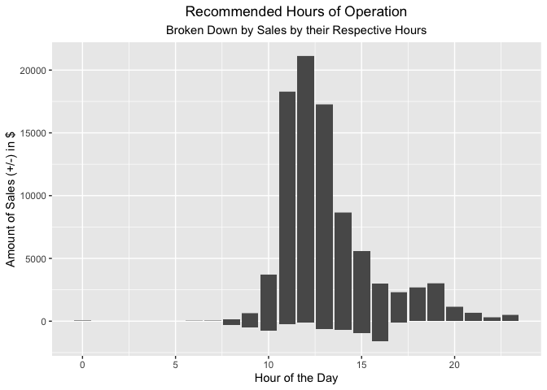

```r
preplot2 <- ggplot(data = hourofoperation, mapping = aes(x = hourofday, y = Amount)) +
  geom_col() +
  labs(title = "Recommended Hours of Operation", subtitle = "Broken Down by Sales by their Respective Hours", x = "Hour of the Day", y = "Amount of Sales (+/-) in $") +
  theme(plot.title = element_text(hjust = .5)) +
  theme(plot.subtitle = element_text(hjust = .5))

preplot2
```

```r
head(hourofoperation)
```

```
## # A tibble: 6 × 3
## # Groups:   Name, hourofday [1]
##   Name       Amount hourofday
##   <chr>       <dbl>     <int>
## 1 Tacontento    3          13
## 2 Tacontento    1.5        13
## 3 Tacontento    3          13
## 4 Tacontento    3          13
## 5 Tacontento    1.5        13
## 6 Tacontento    1          13
```

[figure not shown]

```r
preplot2 + transition_states(hourofday, transition_length = 2, state_length = 1) + shadow_mark() + ease_aes('sine-in-out')
```

Saving as gif

```r
anim_save('preplot2.gif', animation = last_animation(), path = '/Users/hayden/Desktop/FA22 Classes/Data Visualization - Repository/DTS-350/Repository/DTS-350/Week12/Task20')
```